# Zadanie 3.5

Aleksandra Brodecka, Michał Stolarczyk

# Plan analizy

Dla każdego państwa, każdej pozycji i każdej grupy tematycznej zadań obliczamy ważone minimum, maksimum, średnią i medianę czasów rozwiązywania zadań oraz ważoną proporcję zadań rozwiązanych poprawnie.

Następnie dla każdej grupy tematycznej zadań klasteryzujemy państwa za pomocą metody hierarchicznej Warda. Zmienne uwzględniane w klasteryzacji to mediana czasów rozwiązywania zadań oraz średnia liczba poprawnie rozwiązanych zadań na każdej pozycji (w sumie 8 zmiennych).

Dla każdej grupy tematycznej rysujemy wykresy rozproszenia frakcji poprawnie rozwiązanych zadań od mediany czasu rozwiązywania dla poszczególnych pozycji. Jeden punkt oznacza jedno pozycjo-państwo. Wyniki klasteryzacji przedstawiamy za pomocą dendogramu oraz mapy świata z zaznaczonymi klastrami. Dla każdego klastra na wykresach liniowych pokazujemy zależności frakcji poprawnie rozwiązanych zadań i czasu rozwiązywania zadań od numeru pozycji zadania.

# Wnioski

Kraje różnią się pod względem czasów rozwiązywania i wyników zadań. Najlepiej wypadają państwa azjatyckie takie jak: Japonia, Korea, Chiny, Hongkong. Najsłabiej natomiast wypadają państwa Ameryki Łacińskiej takie jak: Meksyk, Brazylia, Peru i Kolumbia. Uczniowie poświęcają znacznie więcej czasu na zadania na pozycji pierwszej i trzeciej niż drugiej i czwartej, co może świadczyć o tym, że nie starcza im czasu na rozwiązanie wszystkich zadań.

# Wczytanie danych i pakietów

```r
library(rworldmap)
library(dplyr)
library(matrixStats)
library(ggplot2)
library(stringi)
library(knitr)
library(tidyr)
library(gridExtra)
source("http://addictedtor.free.fr/packages/A2R/lastVersion/R/code.R")

dane <- readRDS("zadanie0_wynik.rds")
dane <- filter(dane, BOOKID >= 31 & BOOKID <= 61, !is.na(position))
cbPalette <- c("#E69F00", "#56B4E9", "#009E73", "#ad2803",
               "#CC79A7")
```

# Obliczenie statystyk

```r
dane %>%
    select(CNTRYID, CNT, item, result, timing, W_FSTUWT, position) %>%
    mutate(result = as.integer(result == "Full credit"),
           group = stri_sub(item, 2, 2),
           timing = timing / 1000) %>%
    group_by(CNTRYID, CNT, group, position) %>%
    summarise(TimeAvg = weighted.mean(timing, W_FSTUWT, na.rm = TRUE ),
              TimeMin = min(timing, na.rm = TRUE),
              TimeMax = max(timing, na.rm = TRUE),
              TimeMed = weightedMedian(timing, W_FSTUWT, na.rm = TRUE),
              FreqFull = weighted.mean(result, W_FSTUWT, na.rm = TRUE)) %>%
    ungroup() ->
    statystyki
knitr::kable(head(statystyki, 15))
```

| CNTRYID | CNT | group | position | TimeAvg | TimeMin | TimeMax | TimeMed | FreqFull |
| --- | --- | --- | --- | --- | --- | --- | --- | --- |
| Australia | AUS | M | 1 | 85.80054 | 0.615 | 1298.328 | 73.18242 | 0.5423753 |
| Australia | AUS | M | 2 | 81.20017 | 0.362 | 2133.808 | 69.07279 | 0.5490362 |
| Australia | AUS | M | 3 | 78.40108 | 0.567 | 2218.918 | 65.59833 | 0.5254566 |
| Australia | AUS | M | 4 | 75.64252 | 0.703 | 3044.338 | 62.27672 | 0.5231164 |
| Australia | AUS | R | 1 | 61.54683 | 0.379 | 3374.400 | 46.30825 | 0.6294228 |
| Australia | AUS | R | 2 | 54.53910 | 0.547 | 4408.081 | 40.54200 | 0.6024161 |
| Australia | AUS | R | 3 | 56.57013 | 0.370 | 2599.530 | 41.43063 | 0.5877047 |
| Australia | AUS | R | 4 | 51.48855 | 0.454 | 2483.356 | 37.28372 | 0.5591392 |
| Australia | AUS | S | 1 | 66.18345 | 0.274 | 1843.470 | 57.47800 | 0.5758577 |
| Australia | AUS | S | 2 | 57.95927 | 0.466 | 43778.316 | 48.34058 | 0.5535943 |
| Australia | AUS | S | 3 | 63.21295 | 0.456 | 5020.727 | 52.83500 | 0.5689073 |
| Australia | AUS | S | 4 | 54.77749 | 0.413 | 3260.758 | 45.52256 | 0.5380584 |
| Austria | AUT | M | 1 | 87.53648 | 1.109 | 1011.330 | 75.55991 | 0.5386527 |
| Austria | AUT | M | 2 | 82.55076 | 0.524 | 1146.183 | 71.10951 | 0.5543054 |
| Austria | AUT | M | 3 | 76.52611 | 0.445 | 807.731 | 65.09077 | 0.5282292 |

Poniżej przekształcamy dane do postaci szerokiej, która będzie potrzebna do klasteryzacji.

```r
statystyki %>%
    select(CNTRYID, group, position, TimeMed) %>%
    mutate(position = paste0("TimeMed", position)) %>%
    spread(position, TimeMed) -> time_spread

statystyki %>%
    select(CNTRYID, group, position, FreqFull) %>%
    mutate(position = paste0("FreqFull", position)) %>%
    spread(position, FreqFull) -> freq_spread

stats_spread <- merge(time_spread, freq_spread)

knitr::kable(head(stats_spread, 15))
```

| CNTRYID | group | TimeMed1 | TimeMed2 | TimeMed3 | TimeMed4 | FreqFull1 | FreqFull2 | FreqFull3 | FreqFull4 |
| --- | --- | --- | --- | --- | --- | --- | --- | --- | --- |
| Australia | M | 73.18242 | 69.07279 | 65.59833 | 62.27672 | 0.5423753 | 0.5490362 | 0.5254566 | 0.5231164 |
| Australia | R | 46.30825 | 40.54200 | 41.43063 | 37.28372 | 0.6294228 | 0.6024161 | 0.5877047 | 0.5591392 |
| Australia | S | 57.47800 | 48.34058 | 52.83500 | 45.52256 | 0.5758577 | 0.5535943 | 0.5689073 | 0.5380584 |
| Austria | M | 75.55991 | 71.10951 | 65.09077 | 62.97139 | 0.5386527 | 0.5543054 | 0.5282292 | 0.5351262 |
| Austria | R | 43.57673 | 38.70149 | 37.35454 | 34.07663 | 0.6488048 | 0.5946537 | 0.5960475 | 0.5692253 |
| Austria | S | 57.70000 | 49.19300 | 52.09450 | 45.48996 | 0.5622518 | 0.5375331 | 0.5615509 | 0.5442071 |
| B-S-J-G (China) | M | 70.91372 | 60.78818 | 62.00305 | 58.71579 | 0.5873713 | 0.5911364 | 0.5852910 | 0.5796110 |
| B-S-J-G (China) | R | 34.84499 | 28.94940 | 31.46231 | 28.79761 | 0.6225870 | 0.6029541 | 0.6187190 | 0.5998023 |
| B-S-J-G (China) | S | 47.17706 | 36.26654 | 42.50282 | 35.68895 | 0.5839509 | 0.5608081 | 0.5849244 | 0.5517534 |
| Belgium | M | 80.60600 | 75.08371 | 70.58705 | 68.46948 | 0.5796236 | 0.5803321 | 0.5570960 | 0.5655686 |
| Belgium | R | 47.75257 | 42.60230 | 42.70821 | 39.30676 | 0.6506545 | 0.6381310 | 0.6100069 | 0.5898051 |
| Belgium | S | 63.62020 | 52.94500 | 57.29386 | 49.04818 | 0.5629417 | 0.5474290 | 0.5573732 | 0.5389852 |
| Brazil | M | 113.23641 | 82.32000 | 86.65861 | 70.25279 | 0.3144361 | 0.3275116 | 0.3116900 | 0.3093626 |
| Brazil | R | 73.61843 | 54.11494 | 58.89939 | 46.13925 | 0.5079976 | 0.4731527 | 0.4646696 | 0.4351314 |
| Brazil | S | 88.08420 | 56.22184 | 70.74353 | 49.25158 | 0.3912266 | 0.3547214 | 0.3679270 | 0.3309943 |

# Funkcje pomocnicze

```r
freq_vs_time_plot <- function(df, title = "") {

    mutate(df, position = factor(position)) %>%
        ggplot(aes(x=TimeMed, y=FreqFull, color = position)) +
        geom_point(size=2) +
        geom_smooth(method="lm", se=FALSE) +
        labs(x="Czas odpowiedzi (s)",
             y="Frakcja poprawnych odpowiedzi") +
        ggtitle(title)


}

dendogram <- function(df, gr) {
    filter(df, group == gr) -> df_filtered

    rownames(df_filtered) <- df_filtered$CNTRYID
    select(df_filtered, -CNTRYID, -group) %>%
        scale(center=TRUE, scale=TRUE) %>%
        dist() ->
        distance_matrix

    hc <- hclust(distance_matrix, method="ward.D")
    x <- A2Rplot(hc, k = 5, boxes = FALSE,
            col.up = "gray50", col.down = cbPalette)
    ._a2r_envir$groups.o
}


statystyki %>%
    select(CNTRYID, CNT) %>%
    distinct() ->
    country_dict

country_cluster <- function(kl) {
    data.frame(CNTRYID = names(kl),
               clust = factor(kl)) %>%
        left_join(country_dict, by = "CNTRYID")
}


time_vs_position_plot <- function(df, title="") {
    df %>%
        mutate(clust = factor(clust)) %>%
        group_by(position, clust) %>%
        summarise(TimeMed = mean(TimeMed)) %>%
        ggplot(aes(x=position, y=TimeMed, color = clust)) +
        geom_line(size = 2) +
        labs(x="Pozycja", y="Czas odpowiedzi") +
        ggtitle(title) +
        scale_color_manual(values = cbPalette)
}

freq_vs_position_plot <- function(df, title="") {
    df %>%
        mutate(clust = factor(clust)) %>%
        group_by(position, clust) %>%
        summarise(FreqFull = mean(FreqFull)) %>%
        ggplot(aes(x=position, y=FreqFull, color = clust)) +
        geom_line(size = 2) +
        labs(x="Pozycja", y="Frakcja poprawnych odpowiedzi") +
        ggtitle(title) +
        scale_color_manual(values = cbPalette)

}


clusters_map_plot <- function(clusters) {
    capture.output(
        country_data <- joinCountryData2Map(clusters,
                                            joinCode = "NAME",
                                            nameJoinColumn = "CNTRYID")
    )
    mapCountryData(country_data,
                   aspect = 1,
                   nameColumnToPlot="clust",
                   mapTitle = 'Wynik klasteryzacji na mapie',
                   colourPalette = cbPalette)
}

plots <- function(df, clusters, title = "") {
    df <- left_join(df, kl_R, by = c("CNTRYID", "CNT"))
    print(time_vs_position_plot(df, title))
    print(freq_vs_position_plot(df, title))
    clusters_map_plot(df)
}
```

# Wyniki

## Czytanie

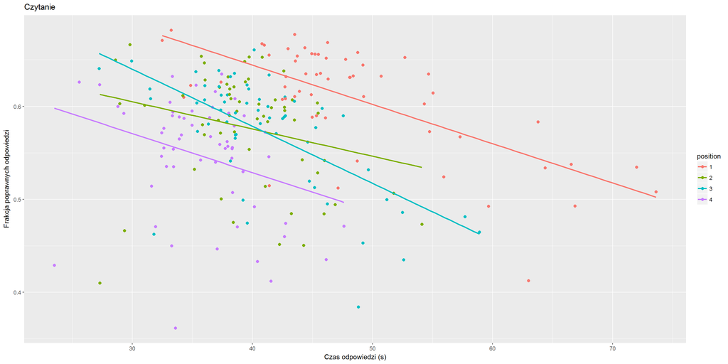

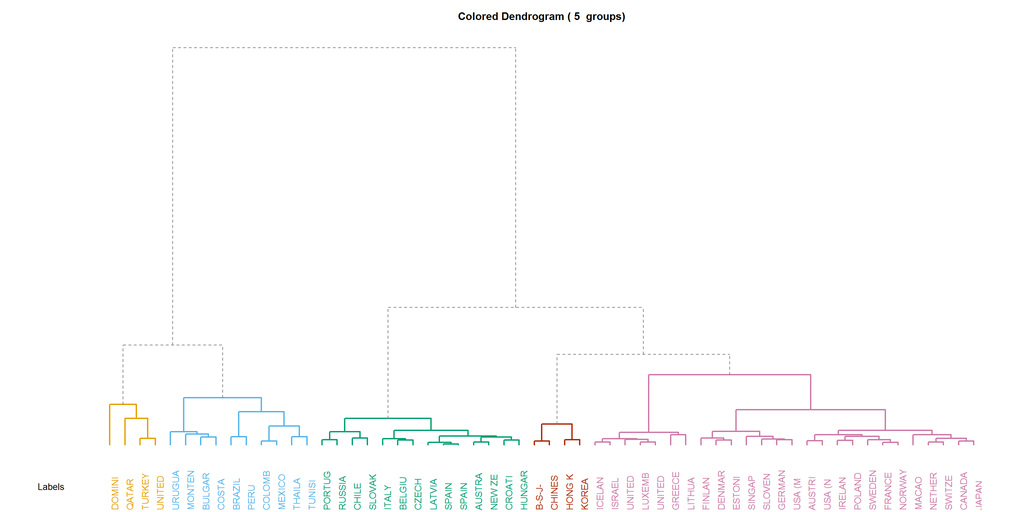

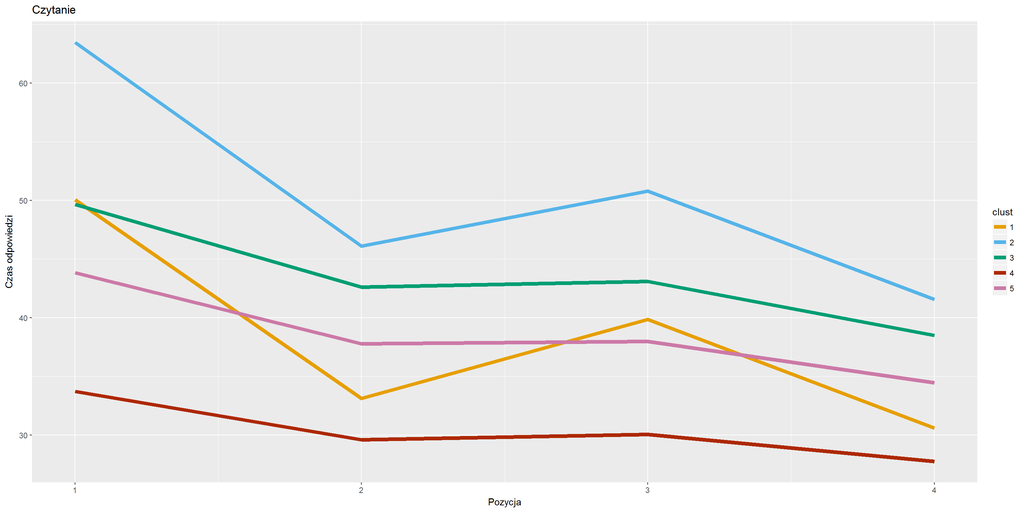

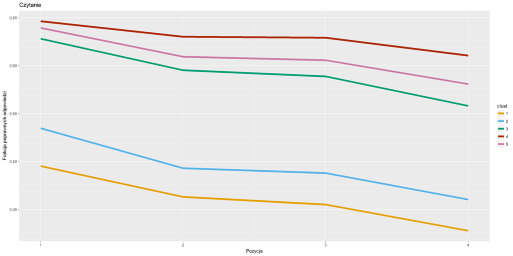

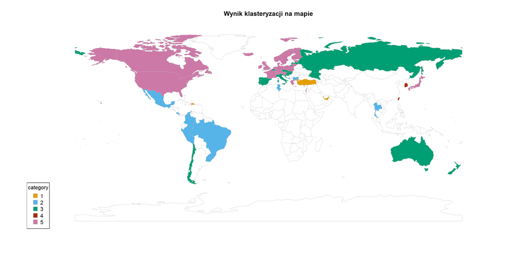

```r
statystyki %>%
    filter(group == "R") %>%
    freq_vs_time_plot("Czytanie") %>%
    print()
kl_R <- country_cluster(dendogram(stats_spread, "R"))
statystyki %>% filter(group=="R") %>%
    plots(kl_R, "Czytanie")
```

## Matematyka

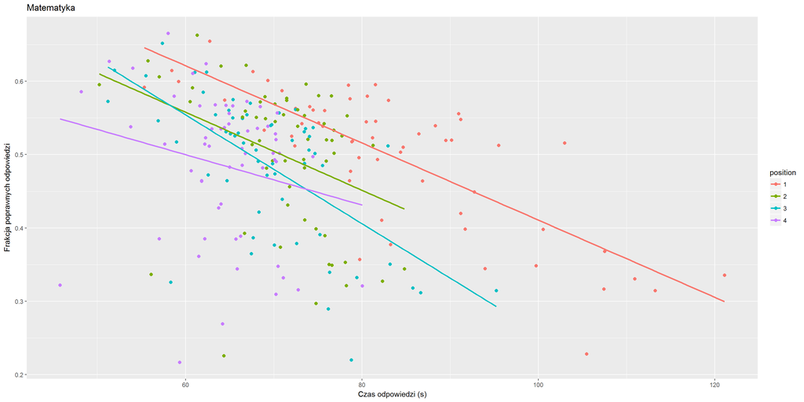

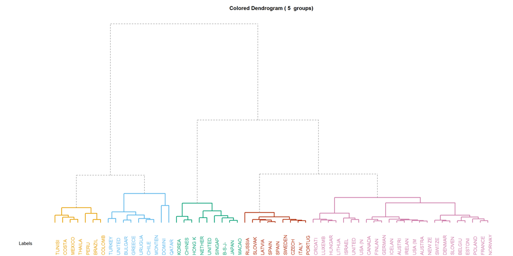

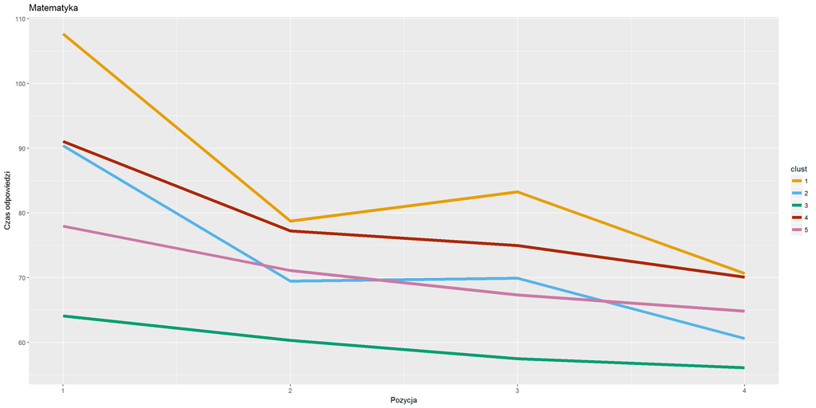

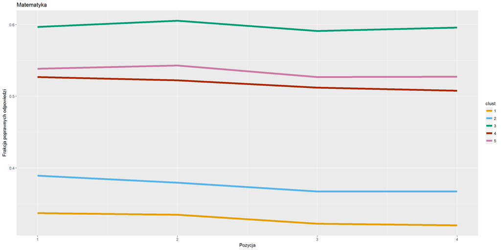

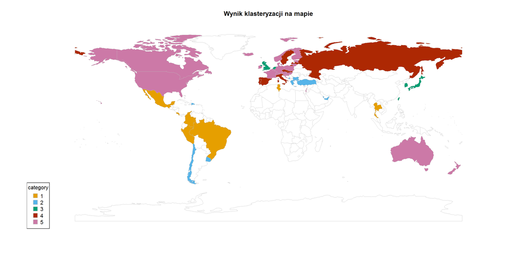

```r
statystyki %>%
    filter(group == "M") %>%
    freq_vs_time_plot("Matematyka") %>%
    print()
kl_R <- country_cluster(dendogram(stats_spread, "M"))
statystyki %>% filter(group=="M") %>%
    plots(kl_R, "Matematyka")
```

## Nauki przyrodnicze

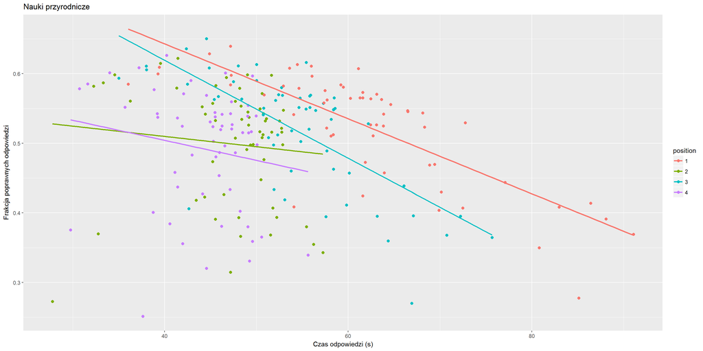

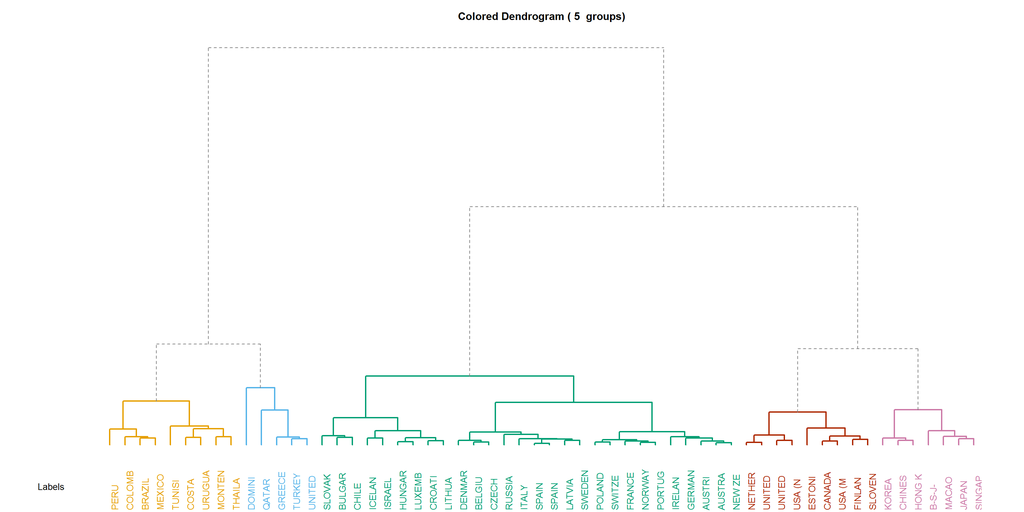

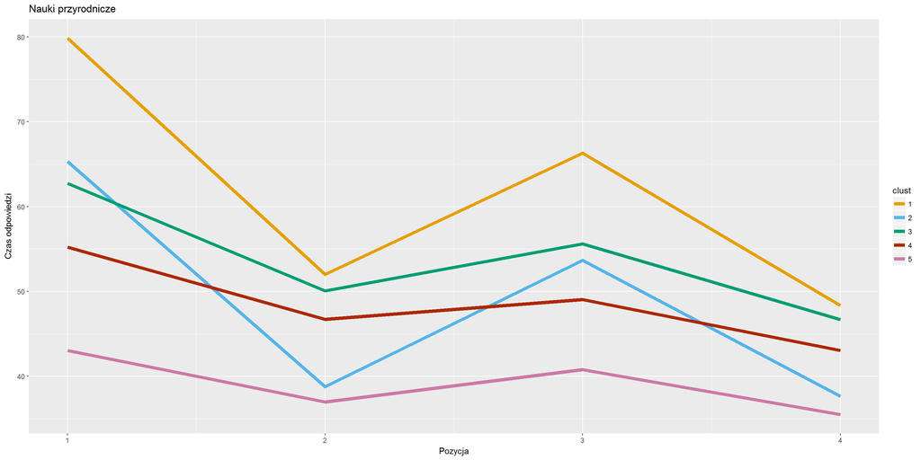

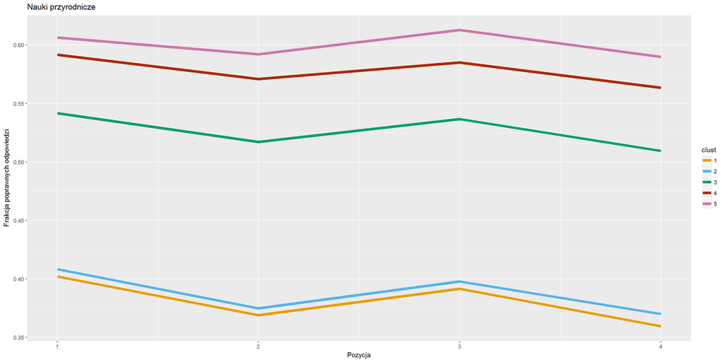

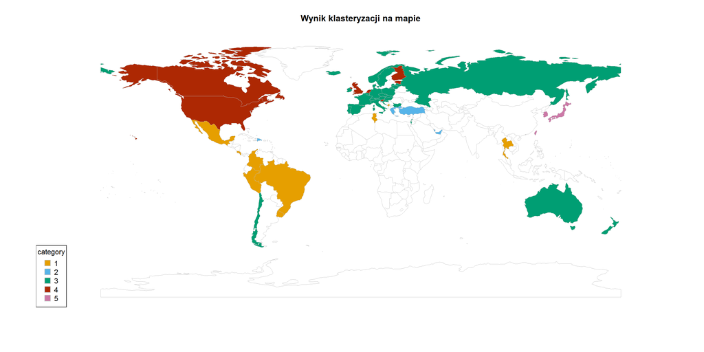

```r
statystyki %>%
    filter(group == "S") %>%
    freq_vs_time_plot("Nauki przyrodnicze") %>%
    print()
kl_R <- country_cluster(dendogram(stats_spread, "S"))
statystyki %>% filter(group=="S") %>%
    plots(kl_R, "Nauki przyrodnicze")
```